# The 3PT Revolution: A Statistical Dive into the NBA

Author

Kian Parchekani

Published

April 11, 2023

## Intro

For my final project, I want to dig deep into a subject that greatly interests me; the NBA. Today, as books like ‘Moneyball’ have shown, statistics are a driving force in modern sports, and many people such as myself have taken inspiration and began doing their own research into the numbers surrounding the game. The way the game is played now has changed because of that; for example, more three pointers are being shot than ever, and teams play with a much higher pace to maximize scoring potential. I have gone over many works of people doing their own academic work on the subject, and some doing research for their own love of the game. Journals such as [Age of Revolutions](https://ageofrevolutions.com/2019/02/25/data-science-and-the-3-point-revolution-in-the-nba/) host their own peer reviewed journals on the ever changing landscape of the NBA, and even prestigous universities such as MIT feature works on this topic. [Understanding Features of Successful 3 Point Shots in the NBA](https://www.mit.edu/~nbailey/files/3ptreport.pdf), and academic paper by Nate Bailey, features a very in depth look at what consititues a good shot (utilizing data from the 2015-16 NBA season) from a statistical perspective. Works such as these show just how far data science has come in the world of sports, and they helped inspire me. Plenty of people have done their part in moving the game forward, I hope to be able to find my own research provides insight.

## Research Question

My research question is “what factors are the best for predicting shooting ability”. Shooting is massive in today’s NBA, as almost every player needs to be able to stretch the floor. Many have done research on the topic, but I wanted to look at existing variables tethered to each player rather than a map of all their shots. Building a model that could help assess prospects shooting ability could be useful to NBA general managers, as well as the players themselves.

## Data

My data is regular season data encapsulating the 2021-2022 NBA Season, and was found on [Kaggle](https://kaggle.com). It features 812 entries (every player to play at least one minute in this season), with thirty columns. These columns encapsulate most basketball statistics; PPG, RPG, APG, 3PT%, etc. They are very useful stats for building a model of any sort. However, I realized further down the road that this dataset did not have certain variables that I deemed potentially useful, so I found a second dataset revolving around the same season that included these variables.

## Cleaning the data

To begin with, I wanted to clean out my dataset, join it with another that featured relevant variables, and filter my data to the entries where my research question was applicable. For that, I began by importing relevant packages, as well as my datasets.

```python
import pandas as pd
import numpy as np
import seaborn as sns
import matplotlib.pyplot as plt
nba = pd.read_csv('/Users/kianparchekani/STAT3255/final-project-KianParchekani/data/nbaregszn_22.csv', encoding="Windows-1252", delimiter=";")
nba2 = pd.read_csv('/Users/kianparchekani/STAT3255/final-project-KianParchekani/data/active_players_2.csv', usecols=['Name', 'Height', 'Weight', 'Salary'])
nba2.head()
```

|  | Name | Height | Weight | Salary |
| --- | --- | --- | --- | --- |
| 0 | Juhann Begarin | 6' 5" | 185 | NaN |
| 1 | Jaylen Brown | 6' 6" | 223 | 26758928.0 |
| 2 | Kris Dunn | 6' 3" | 205 | 5005350.0 |
| 3 | Carsen Edwards | 5' 11" | 200 | 1782621.0 |
| 4 | Tacko Fall | 7' 5" | 311 | NaN |

First, I removed entries for players that played for multiple teams in the same season, keeping only their total stats rather than the seperate entries for each team. Then, I joined the two datasets, and only included the values from the second that were needed, as many columns were redundant.

```python
# Filter nba dataset to keep only the "TOT" rows for players with multiple rows
nba = nba.groupby('Player').apply(lambda x: x[x['Tm'] == 'TOT'] if len(x) > 1 else x).reset_index(drop=True)

# Join data frames
nba = pd.merge(nba, nba2, left_on='Player', right_on='Name', how='left')

# Drop the redundant "Name" column
nba = nba.drop('Name', axis=1)

# Print final data frame
nba.head()
```

|  | Rk | Player | Pos | Age | Tm | G | GS | MP | FG | FGA | ... | TRB | AST | STL | BLK | TOV | PF | PTS | Height | Weight | Salary |
| --- | --- | --- | --- | --- | --- | --- | --- | --- | --- | --- | --- | --- | --- | --- | --- | --- | --- | --- | --- | --- | --- |
| 0 | 198 | Aaron Gordon | PF | 26 | DEN | 75 | 75 | 31.7 | 5.8 | 11.1 | ... | 5.9 | 2.5 | 0.6 | 0.6 | 1.8 | 2.0 | 15.0 | 6' 8" | 235.0 | 16409091.0 |
| 1 | 233 | Aaron Henry | SF | 22 | PHI | 6 | 0 | 2.8 | 0.2 | 0.8 | ... | 0.2 | 0.0 | 0.0 | 0.3 | 0.3 | 0.3 | 0.3 | 6' 6" | 210.0 | NaN |
| 2 | 244 | Aaron Holiday | PG | 25 | TOT | 63 | 15 | 16.2 | 2.4 | 5.4 | ... | 1.9 | 2.4 | 0.7 | 0.1 | 1.1 | 1.5 | 6.3 | 6' 0" | 185.0 | 3980551.0 |
| 3 | 406 | Aaron Nesmith | SF | 22 | BOS | 52 | 3 | 11.0 | 1.4 | 3.5 | ... | 1.7 | 0.4 | 0.4 | 0.1 | 0.6 | 1.3 | 3.8 | 6' 5" | 215.0 | 3631200.0 |
| 4 | 581 | Aaron Wiggins | SG | 23 | OKC | 50 | 35 | 24.2 | 3.1 | 6.7 | ... | 3.6 | 1.4 | 0.6 | 0.2 | 1.1 | 1.9 | 8.3 | 6' 5" | 190.0 | NaN |

5 rows × 33 columns

Next, I would like to make use of the ‘Height’ column in the future. In order to do that, I need to convert the values into numerical values.

```python
import re

# Define a function to convert the values in the "Height" column into inches
def convert_height(height_str):
    pattern = re.compile(r"(?P<feet>\d)' (?P<inches>\d+)\"")
    match = pattern.search(height_str)
    if match:
        feet = int(match.group('feet'))
        inches = int(match.group('inches'))
        return feet * 12 + inches
    else:
        return None

# Apply the function to the "Height" column and store the result in a new column called "Height_inches"
nba['Height_inches'] = nba['Height'].astype(str).apply(convert_height)

# Create a secondary column for "Height" in feet
nba['Height_feet'] = nba['Height_inches'].apply(lambda x: x /12)

# Test
nba.head()
```

|  | Rk | Player | Pos | Age | Tm | G | GS | MP | FG | FGA | ... | STL | BLK | TOV | PF | PTS | Height | Weight | Salary | Height_inches | Height_feet |
| --- | --- | --- | --- | --- | --- | --- | --- | --- | --- | --- | --- | --- | --- | --- | --- | --- | --- | --- | --- | --- | --- |
| 0 | 198 | Aaron Gordon | PF | 26 | DEN | 75 | 75 | 31.7 | 5.8 | 11.1 | ... | 0.6 | 0.6 | 1.8 | 2.0 | 15.0 | 6' 8" | 235.0 | 16409091.0 | 80.0 | 6.666667 |
| 1 | 233 | Aaron Henry | SF | 22 | PHI | 6 | 0 | 2.8 | 0.2 | 0.8 | ... | 0.0 | 0.3 | 0.3 | 0.3 | 0.3 | 6' 6" | 210.0 | NaN | 78.0 | 6.500000 |
| 2 | 244 | Aaron Holiday | PG | 25 | TOT | 63 | 15 | 16.2 | 2.4 | 5.4 | ... | 0.7 | 0.1 | 1.1 | 1.5 | 6.3 | 6' 0" | 185.0 | 3980551.0 | 72.0 | 6.000000 |
| 3 | 406 | Aaron Nesmith | SF | 22 | BOS | 52 | 3 | 11.0 | 1.4 | 3.5 | ... | 0.4 | 0.1 | 0.6 | 1.3 | 3.8 | 6' 5" | 215.0 | 3631200.0 | 77.0 | 6.416667 |
| 4 | 581 | Aaron Wiggins | SG | 23 | OKC | 50 | 35 | 24.2 | 3.1 | 6.7 | ... | 0.6 | 0.2 | 1.1 | 1.9 | 8.3 | 6' 5" | 190.0 | NaN | 77.0 | 6.416667 |

5 rows × 35 columns

To go along with that, I decided to convert the positions to numerical values (1-5) rather than the names of the positons.

```python
nba['Pos'] = nba['Pos'].apply(lambda x: x.split('-')[0])
nba['Pos'] = nba['Pos'].replace({'PG': 1, 'SG': 2, 'SF': 3, 'PF': 4, 'C': 5})
```

We need to filter this data a bit so we don’t have any massive outliers, so let’s only account for players who have shot at least 100 3PT shots, and players that have played in at least 20 games.

```python
# Filter the dataset to only include entries with more than 20 in 'G'
nba = nba[nba['G'] > 20]

# Create a new column '3PA_total' by multiplying '3PA' with 'G'
nba['3PA_total'] = nba['3PA'] * nba['G']
# Create a new column '3P_total' by multiplying '3P' with 'G'
nba['3P_total'] = nba['3P'] * nba['G']

# Filter the dataset to only include players with more than 100 3-point attempts
nba = nba[nba['3PA_total'] > 100]
```

```python
nba.head(10)
```

|  | Rk | Player | Pos | Age | Tm | G | GS | MP | FG | FGA | ... | TOV | PF | PTS | Height | Weight | Salary | Height_inches | Height_feet | 3PA_total | 3P_total |
| --- | --- | --- | --- | --- | --- | --- | --- | --- | --- | --- | --- | --- | --- | --- | --- | --- | --- | --- | --- | --- | --- |
| 0 | 198 | Aaron Gordon | 4 | 26 | DEN | 75 | 75 | 31.7 | 5.8 | 11.1 | ... | 1.8 | 2.0 | 15.0 | 6' 8" | 235.0 | 16409091.0 | 80.0 | 6.666667 | 262.5 | 90.0 |
| 2 | 244 | Aaron Holiday | 1 | 25 | TOT | 63 | 15 | 16.2 | 2.4 | 5.4 | ... | 1.1 | 1.5 | 6.3 | 6' 0" | 185.0 | 3980551.0 | 72.0 | 6.000000 | 100.8 | 37.8 |
| 3 | 406 | Aaron Nesmith | 3 | 22 | BOS | 52 | 3 | 11.0 | 1.4 | 3.5 | ... | 0.6 | 1.3 | 3.8 | 6' 5" | 215.0 | 3631200.0 | 77.0 | 6.416667 | 114.4 | 31.2 |
| 4 | 581 | Aaron Wiggins | 2 | 23 | OKC | 50 | 35 | 24.2 | 3.1 | 6.7 | ... | 1.1 | 1.9 | 8.3 | 6' 5" | 190.0 | NaN | 77.0 | 6.416667 | 140.0 | 40.0 |
| 9 | 250 | Al Horford | 5 | 35 | BOS | 69 | 69 | 29.1 | 3.9 | 8.2 | ... | 0.9 | 1.9 | 10.2 | 6' 9" | 240.0 | 27000000.0 | 81.0 | 6.750000 | 262.2 | 89.7 |
| 10 | 85 | Alec Burks | 2 | 30 | NYK | 81 | 44 | 28.6 | 3.5 | 9.0 | ... | 1.1 | 2.7 | 11.7 | 6' 6" | 214.0 | 9536000.0 | 78.0 | 6.500000 | 388.8 | 153.9 |
| 12 | 448 | Aleksej Pokusevski | 4 | 20 | OKC | 61 | 12 | 20.2 | 3.0 | 7.5 | ... | 1.5 | 1.4 | 7.6 | 7' 0" | 190.0 | 3113160.0 | 84.0 | 7.000000 | 195.2 | 54.9 |
| 13 | 97 | Alex Caruso | 2 | 27 | CHI | 41 | 18 | 28.0 | 2.5 | 6.2 | ... | 1.4 | 2.6 | 7.4 | 6' 4" | 186.0 | 8650651.0 | 76.0 | 6.333333 | 127.1 | 41.0 |
| 17 | 497 | Alperen Þengün | 5 | 19 | HOU | 72 | 13 | 20.7 | 3.5 | 7.3 | ... | 2.0 | 3.0 | 9.6 | NaN | NaN | NaN | NaN | NaN | 115.2 | 28.8 |
| 18 | 109 | Amir Coffey | 2 | 24 | LAC | 69 | 30 | 22.7 | 3.1 | 6.8 | ... | 0.7 | 1.3 | 9.0 | 6' 7" | 210.0 | NaN | 79.0 | 6.583333 | 255.3 | 96.6 |

10 rows × 37 columns

## Data Exploration

Before going any further, I wanted to visualize by data a bit. I wanted to look at the statistics I am evaluating with this project, as well as evaluating any potential patterns.

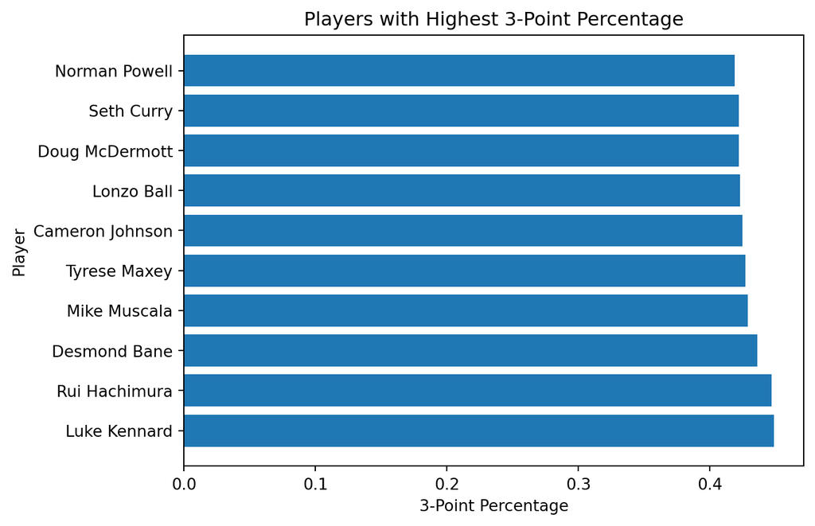

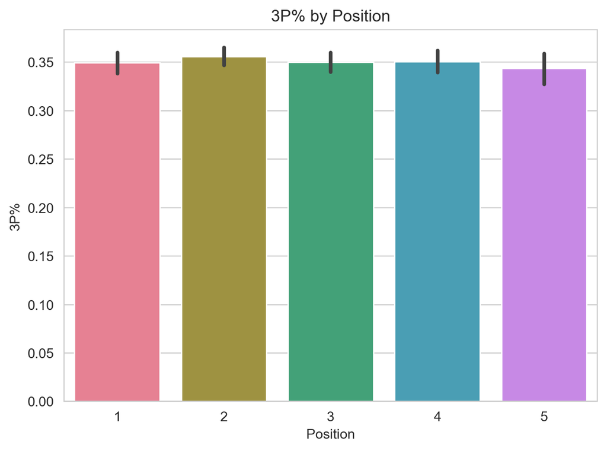

```python
# get top 10 players with highest 3P%
top10 = nba.sort_values(by='3P%', ascending=False)[:10]

# Plot the highest 3-point percentages

plt.barh(top10['Player'], top10['3P%'])

plt.title('Players with Highest 3-Point Percentage')
plt.xlabel('3-Point Percentage')
plt.ylabel('Player')
plt.show()

# show the plot
plt.show()

sns.set_style('whitegrid')

# Create bar chart of 3P% by Pos
sns.barplot(x='Pos', y='3P%', data=nba, palette=sns.color_palette('husl', n_colors=len(nba['Pos'].unique())))


plt.title('3P% by Position')
plt.xlabel('Position')
plt.ylabel('3P%')
plt.show()
```

After that, I wanted to take a look at how 3P% compares to how many 3Ps a player has made total.

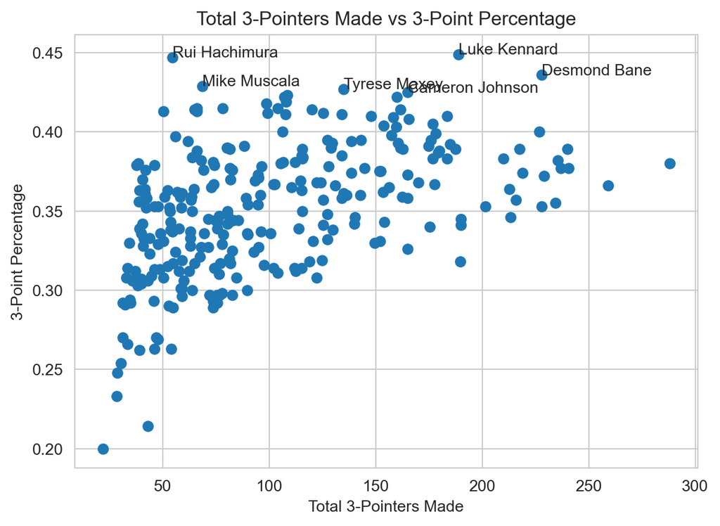

```python
# Create a scatterplot of '3P_total' vs '3P%'
plt.scatter(nba['3P_total'], nba['3P%'])

# Label distinct points that could be worth examining further
high_3pt_pct = nba[nba['3P%'] >= 0.425] # select players with 3P% >= 0.425
high_3pt_total = high_3pt_pct[high_3pt_pct['3P_total'] > 50] # select players with 3P_total > 50
for i, row in high_3pt_total.iterrows():
    plt.annotate(row['Player'], (row['3P_total'], row['3P%']))

# Add axis labels and title
plt.xlabel('Total 3-Pointers Made')
plt.ylabel('3-Point Percentage')
plt.title('Total 3-Pointers Made vs 3-Point Percentage')

# Display the plot
plt.show()
```

From there, I wanted to take a look at what age ranges shoot the best, and to see if I could draw any conclusions from the visuals.

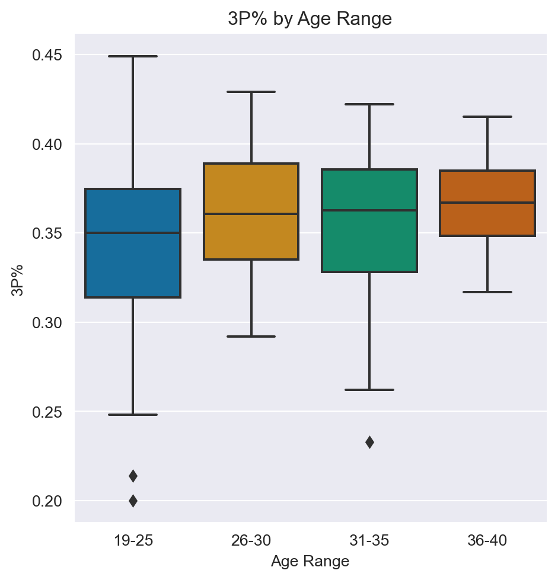

```python
# Create age ranges
bins = [19, 25, 30, 35, 40]

# Define colors for each age range
colors = sns.color_palette("colorblind", len(bins))

# Add labels for each age range
labels = ['19-25', '26-30', '31-35', '36-40']

# Create a new column for age range
nba['AgeRange'] = pd.cut(nba['Age'], bins=bins, labels=labels, include_lowest=True)

# Create the seaborn plot
sns.set_style('darkgrid')
sns.set_palette(colors)
sns.catplot(x='AgeRange', y='3P%', kind='box', data=nba)

# Add plot title and axis labels
plt.title('3P% by Age Range')
plt.xlabel('Age Range')
plt.ylabel('3P%')
plt.show()
```

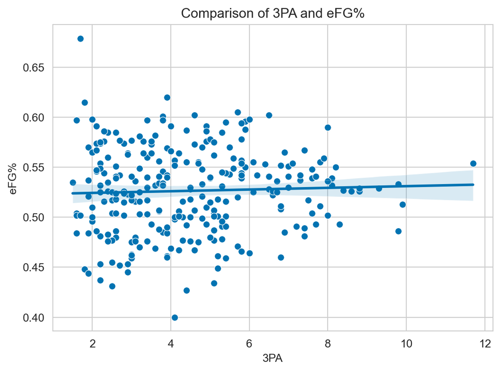

```python
sns.set_style('whitegrid')

# Create scatterplot
sns.scatterplot(x='3PA', y='eFG%', data=nba)

# Add line of best fit
sns.regplot(x='3PA', y='eFG%', data=nba, scatter=False)

# Set axis labels and title
plt.xlabel('3PA')
plt.ylabel('eFG%')
plt.title('Comparison of 3PA and eFG%')

# Show plot
plt.show()
```

Finally, I wanted to take a look at how 3P% compares to FT%

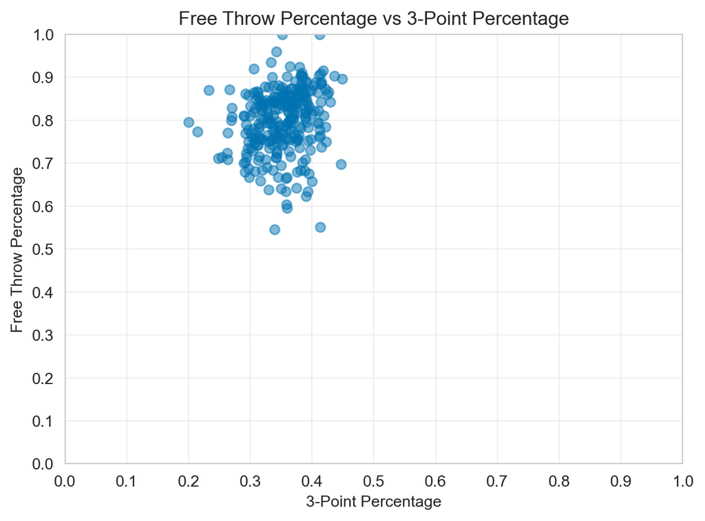

```python
# Create a scatterplot with '3P_total' as the x axis and '3P%' as the y axis
plt.scatter(nba['3P%'], nba['FT%'], alpha=0.5)

# Add labels and title
plt.xlabel('3-Point Percentage')
plt.ylabel('Free Throw Percentage')
plt.title('Free Throw Percentage vs 3-Point Percentage')

# Set the x and y limits and ticks
plt.xlim(0, 1)
plt.xticks([0.1*i for i in range(11)])
plt.ylim(0, 1)
plt.yticks([0.1*i for i in range(11)])

# Add gridlines
plt.grid(True, alpha=0.3)

# Show the plot
plt.show()
```

Despite the previous position vs 3P% graph being inconclusive, I wanted to conduct a hypothesis test just to make sure.

```python
from scipy.stats import chi2_contingency

# create contingency table
cont_table = pd.crosstab(nba['Pos'], nba['3P%'])

# perform chi-squared test
chi2, p, dof, expected = chi2_contingency(cont_table)

# print results
print("Chi-Squared Statistic:", chi2)
print("Degrees of Freedom:", dof)
print("p-value:", p)
```

```
Chi-Squared Statistic: 481.96708242792994
Degrees of Freedom: 528
p-value: 0.9249660171331854
```

## Final Model

For my final model, I decided to go with a Gradient Boosting Regression model, as it works well with numerical data, which makes up most of the data I am working with. For the variables, I ended up using 3P, 3PA, FT%, Height and Salary, as they gave me the best results. The results are plotted against the actual 3P% for each player.

```
MSE: 0.0003
MAE: 0.0121
R-squared: 0.7803396833403606
```

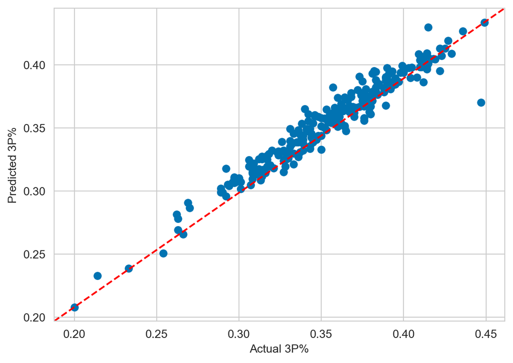

```python
from sklearn.ensemble import GradientBoostingRegressor
from sklearn.model_selection import train_test_split
from sklearn.metrics import mean_squared_error, mean_absolute_error, r2_score

nba = nba.dropna()

# Prepare the data
X = nba[['3P', '3PA', 'FT%', 'Height_inches', 'Salary']]
y = nba['3P%']
X_train, X_test, y_train, y_test = train_test_split(X, y, test_size=0.2, random_state=42)

# Train the model
model = GradientBoostingRegressor(random_state=42)
model.fit(X_train, y_train)

# Make predictions on the test set
y_pred = model.predict(X_test)

# Calculate the mean squared error (MSE) of the predictions
mse = mean_squared_error(y_test, y_pred)
mae = mean_absolute_error(y_test, y_pred)
print(f'MSE: {mse:.4f}')
print(f'MAE: {mae:.4f}')
# calculate R-squared value
r2 = r2_score(y_test, y_pred)
print("R-squared:", r2)

# Add the predictions to a new column in the dataframe
nba['Pred_3P%'] = model.predict(X)

# Plot the actual 3P% vs. the predicted 3P%

plt.scatter(nba['3P%'], nba['Pred_3P%'])
plt.plot([0, 1], [0, 1], transform=plt.gca().transAxes, ls='--', c='red')  # add perfect fit line
plt.xlabel('Actual 3P%')
plt.ylabel('Predicted 3P%')
plt.show()
```

## Conclusion

In doing this project, I gained some unexpected insight. I went into this project assuming a couple things that were disproven to me; position had much less of an impact than I assumed, but height did have an impact. To go along with that, I expected FT% to have a much larger correlation, and while it did help my model, it was not as drastic as I had originally assumed.